# Water Quality Report for Paradise Creek (PC0.00)

**Monitoring period:** October 03, 2025 through June 03, 2026  
**Data current through:** 2026-06-03  
**Report generated:** 2026-10-02

## About this report

This report summarizes community monitoring results for this location. Results describe conditions observed on the sampling dates and may not represent conditions at other times. State water-quality criteria are provided only as context. A formal compliance determination requires the correct designated use, required calculation period, representative sampling, and other regulatory considerations.

## Data summary

| Parameter | Samples | First date | Last date | Minimum | Mean | Maximum |
| --- | --- | --- | --- | --- | --- | --- |
| Air Temperature Average (ºC) | 7 | 2025-10-03 | 2026-06-03 | 2.25 | 11.75 | 23.0 |
| Water Temperature Average (ºC) | 9 | 2025-10-03 | 2026-06-03 | 3.00 | 9.31 | 19.5 |
| Turbidity (NTU) | 8 | 2025-10-03 | 2026-06-03 | 2.00 | 10.62 | 27.0 |

## State water-quality criteria reference

These are general screening references for parameters in this report. These values help interpret monitoring results but should not be used to determine whether the site meets Washington water-quality standards.A formal assessment requires confirming which standards apply to the specific stream reach and using the evaluation methods required by the Washington State Department of Ecology.

| Parameter | Reference criterion | Important limitation | Source |
| --- | --- | --- | --- |
| Water Temperature Average (ºC) | 17.5 ºC for the salmonid spawning/rearing use category | The criterion is a 7-day average of daily maximum temperatures and cannot be evaluated using a simple field average. | WAC 173-201A-200(1)(c) |
| Turbidity (NTU) | 5 NTU above background when background is 50 NTU or less; otherwise no more than a 10% increase | The applicable increase depends on designated aquatic life use and requires a representative background measurement. | WAC 173-201A-200(1)(e) |

## Parameter results

### Air and water temperature

Air and water temperatures measured at this monitoring site.

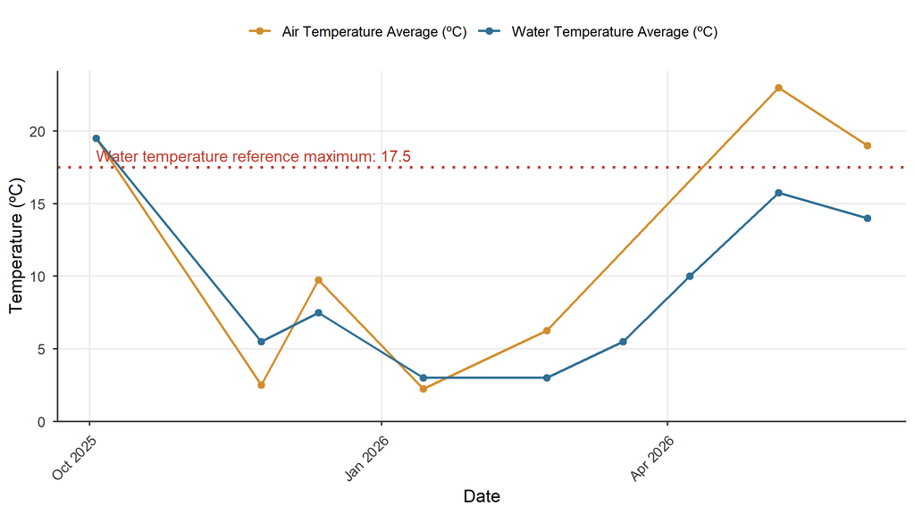

### Turbidity (NTU)

Turbidity in nephelometric turbidity units. Washington’s freshwater turbidity criterion is based on the increase above background and depends on the designated aquatic life use.

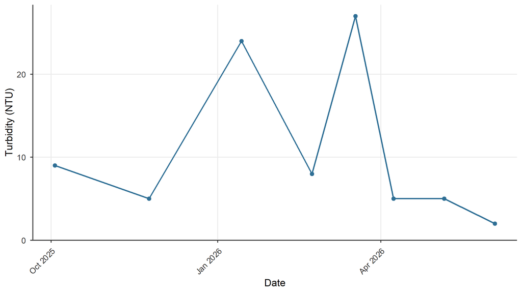

## Data note

This report was generated by the Palouse Conservation District using the Confluence Crew data.